# NBA

```r
library(data.table)
library(tidyverse)
library(summarytools)
library(lubridate)
library(ggplot2)
library(ggcorrplot)
```

# 1. Introduction

Basketball is a popular sport played worldwide, characterized by fast-paced game play, high-scoring action, and a variety of different positions with unique skill sets. Key metrics used to evaluate player performance in basketball include points per game (PPG), rebounds per game (RPG), assists per game (APG), steals per game (SPG), and blocks per game (BPG). This game is played in a court by two teams made up of five players each of which each has his own skill giving him a specific requirements and responsibilities: point guard, shooting guard, small forward, power forward, and center.

In this report, we will analyze the performance of players on the Chicago Bulls team in the NBA (National Basketball Association) during the 2018-2019 season. The Chicago Bulls placed 27th out of 30 teams in the league, with a budget of $118 million for player contracts, which ranked 26th out of 30 teams. Our aim is to identify the best five starting players on the team, one for each position, while staying within the team’s budget constraints.

To achieve this aim, we will be using the Wins Above Replacement (WAR) model, which is a statistical model used to estimate a player’s value to their team compared to a replacement-level player. By calculating each player’s WAR, we can identify which players are contributing the most to the team’s success and should be prioritized for starting positions. We will also consider other relevant metrics such as player salaries and team budget constraints.

This analysis is important as it can provide valuable insights to the team’s management and coaching staff, helping them make informed decisions about player selection and team strategy. By identifying the best starting players, the team can improve their chances of winning games and ultimately improving their overall performance in the league. This potential will have an impact on the team’s fan base, revenue, and overall success in the league.

# 2. Reading and cleaning the raw data

The data comes from multiple CSV files located in the “data/raw” folder.

```r
#Importing a csv files and saving them in form of a list
list_dataframe = list.files(path = "data/raw", pattern = "*.csv") %>%
  paste("data/raw/",.,sep = "") %>%
  lapply(.,function(x) fread(x))
```

## Data Importation

The first step in the data importation process is to import the CSV files and save them as a list of data frames using the `list.files` and `lapply` functions. The `list.files` function returns a vector of file names that match the specified pattern in the specified path. The paste function is used to add the path to each file name. The resulting vector of file names is then passed to the `lapply` function, which applies the fread function to each file to read it into a data frame.

```r
# Merge the first two data frames in the list by player name
Data = merge(list_dataframe[[1]], list_dataframe[[2]], by = "player_name")

# Merge the third and fourth data frames in the list by team
Data1 = merge(list_dataframe[[3]], list_dataframe[[4]], by = "Team")

# Replace LA with Los Angeles in the team names in the fifth data frame
list_dataframe[[5]]$team = gsub("LA", "Los Angeles", list_dataframe[[5]]$team)

# Find the team index for each team name in the fifth data frame
Rk = NULL
for (i in 1:length(list_dataframe[[5]]$team)) {
  Team = grep(list_dataframe[[5]]$team[i], list_dataframe[[4]]$Team)
  Rk = rbind(Rk, Team)
}

# Merge the fifth data frame with the team index to the previous merged data frame
Data2 = merge(Data1, data.frame(list_dataframe[[5]], Rk = Rk), by.x = "Rk.y", by.y = "Rk")

# Replace team names in Data by using abbreviations with full team names
Data$Tm = gsub("BRK|TOT", c("BKN", "TOR"), Data$Tm)
Data$Tm = gsub("CHO", "CHA", Data$Tm)
Data$Tm = gsub("PHO", "PHX", Data$Tm)

# Create a data frame with the NBA team abbreviations and full team names
NBA_Teams = data.frame(
  stringsAsFactors = FALSE,
  check.names = FALSE,
  `Abbreviation` = c("ATL\tAtlanta Hawks","BKN\tBrooklyn Nets",
                      "BOS\tBoston Celtics",
                       "CHA\tCharlotte Hornets","CHI\tChicago Bulls",
                       "CLE\tCleveland Cavaliers","DAL\tDallas Mavericks",
                       "DEN\tDenver Nuggets","DET\tDetroit Pistons",
                       "GSW\tGolden State Warriors",
                      "HOU\tHouston Rockets","IND\tIndiana Pacers",
                       "LAC\tLos Angeles Clippers","LAL\tLos Angeles Lakers",
                       "MEM\tMemphis Grizzlies","MIA\tMiami Heat",
                       "MIL\tMilwaukee Bucks","MIN\tMinnesota Timberwolves",
                       "NOP\tNew Orleans Pelicans","NYK\tNew York Knicks",
                       "OKC\tOklahoma City Thunder",
                      "ORL\tOrlando Magic","PHI\tPhiladelphia 76ers",
                       "PHX\tPhoenix Suns","POR\tPortland Trail Blazers",
                       "SAC\tSacramento Kings","SAS\tSan Antonio Spurs",
                       "TOR\tToronto Raptors",
                      "UTA\tUtah Jazz","WAS\tWashington Wizards")) %>%
  separate(Abbreviation, c("Acronym", "Franchise"), sep = "\t")

# Merge Data and Data2 by the full team name
Data = merge(Data, NBA_Teams, by.x = "Tm", by.y = "Acronym")

# Merge the previous merged data frame with the complete data frame
Complete_Data = merge(Data, Data2, by.x = "Franchise", by.y = "Team")

# Rename the columns to differentiate between player and team variables
names(Complete_Data) = gsub(".x$", "_Player", names(Complete_Data))
names(Complete_Data) = gsub(".y$", "_Team", names(Complete_Data))

# Clean up the salary variable by removing commas and converting to numeric
Complete_Data$salary_Team = gsub(",| ", "", Complete_Data$salary_Team)
Complete_Data$salary_Team=as.numeric(substring(Complete_Data$salary_Team,2))

Complete_Data=Complete_Data %>% dplyr::select(-c(team,team_id,V23,V24,V25))

Complete_Data$Franchise=factor(Complete_Data$Franchise)
Complete_Data$Pos=factor(Complete_Data$Pos)
```

Next, we merge two data frames from the list using the `merge` function. We pass the two data frames as arguments and specify the column to merge by using the `by` parameter.

Then we use the `grep` function in a loop to match the teams from one of the data frames with the other. We save the resulting matches in a new data frame using the `rbind` function.

We merge this new data frame with another data frame from the list using the `merge` function again. We specify the columns to merge by using the `by.x` and `by.y` parameters.

Finally, we merge the resulting data frame with a data frame that contains the abbreviations and names of all NBA teams. We use the merge function again and specify the columns to merge by using the `by.x` and `by.y` parameters.

## Data Cleaning

After importing the data, we perform several cleaning steps. First, we use the `gsub` function to replace the “LA” team abbreviation with “Los Angeles” in the fifth data frame.

Next, we use the `gsub` function again to replace various team abbreviations with their full names in the first data frame. We chain multiple `gsub` functions together to perform multiple replacements in a single step.

We also use the `dplyr::select` function to remove unnecessary columns from the resulting data frame.

Finally, we use the `gsub`, `substring` and `as.numeric` functions to clean up the salary column in the resulting data frame. We remove commas and spaces from the column using `gsub`, then we remove the dollar sign using `substring` and convert the resulting strings to numeric values using `as.numeric`.

# 3. Exploratory analysis

```r
# Summary
#view(dfSummary(Complete_Data))

# extracting columns with missing values
which(sapply(Complete_Data, function(x) any(is.na(x))))
```

```
##  FG%_Player  3P%_Player  2P%_Player eFG%_Player  FT%_Player
##          13          16          19          20          23
```

```r
# handling the missing values
Complete_Data=Complete_Data %>% select(-c(`FG%_Player`,`3P%_Player`,
                                          `2P%_Player`,`eFG%_Player`,
                                          `FT%_Player`))
any(is.na(Complete_Data))
```

```
## [1] FALSE
```

```r
#save the cleaned data file
#write.csv(Complete_Data, file = "data/processed/Clean_data.csv", row.names = F)
```

## Graphs and Tables

### Correlation

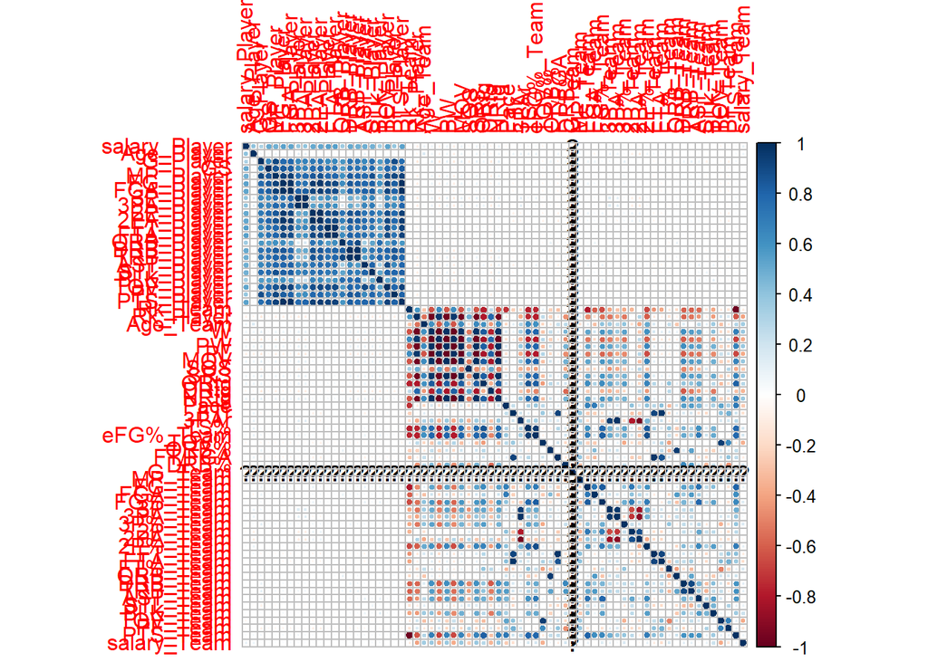

```r
# Check the correlation between the variables
cor_Complete_Data = select(Complete_Data, -c(Tm, player_name,
                                              player_id, Pos,Franchise))
corrplot::corrplot(cor(cor_Complete_Data))
```

### Distribution of the variables

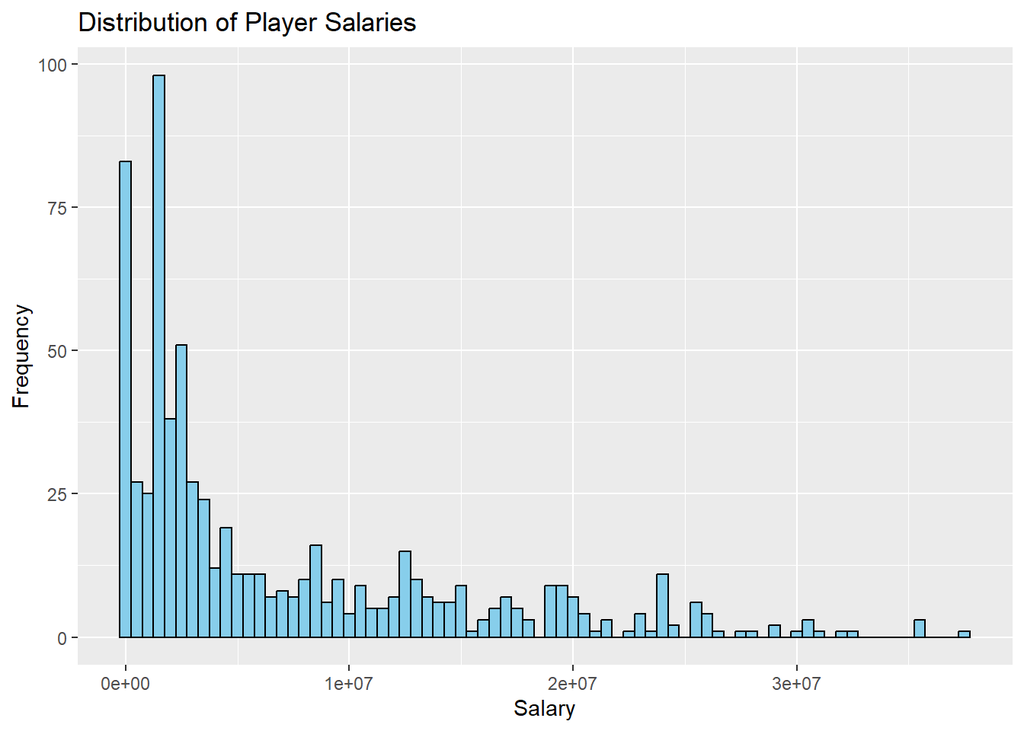

```r
# Visualize the distribution of the variables
ggplot(Complete_Data, aes(x = salary_Player)) +
  geom_histogram(binwidth = 500000, color = "black", fill = "skyblue") +
  ggtitle("Distribution of Player Salaries") +
  xlab("Salary") +
  ylab("Frequency")
```

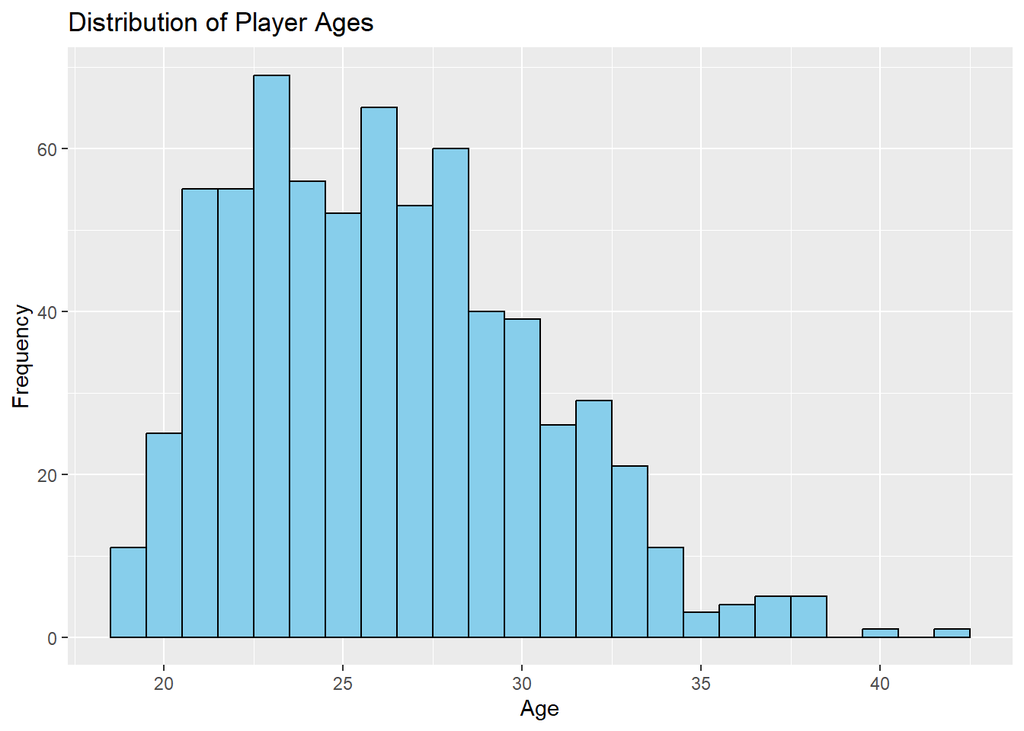

```r
ggplot(Complete_Data, aes(x = Age_Player)) +
  geom_histogram(binwidth = 1, color = "black", fill = "skyblue") +
  ggtitle("Distribution of Player Ages") +
  xlab("Age") +
  ylab("Frequency")
```

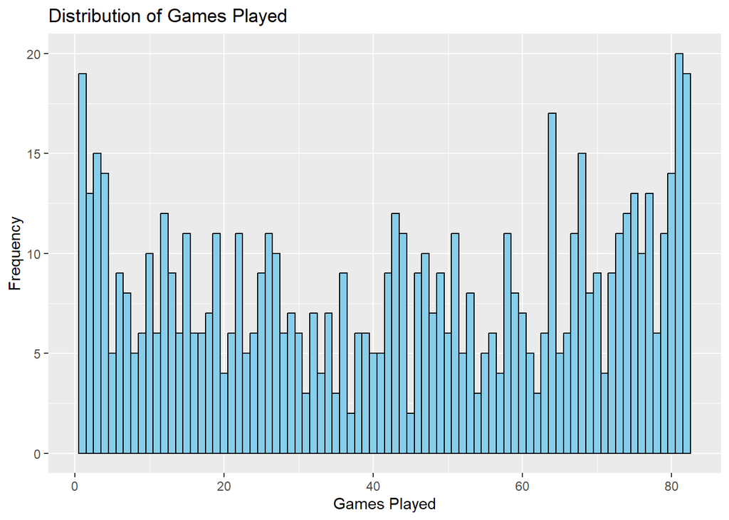

```r
ggplot(Complete_Data, aes(x = G_Player)) +
  geom_histogram(binwidth = 1, color = "black", fill = "skyblue") +
  ggtitle("Distribution of Games Played") +
  xlab("Games Played") +
  ylab("Frequency")
```

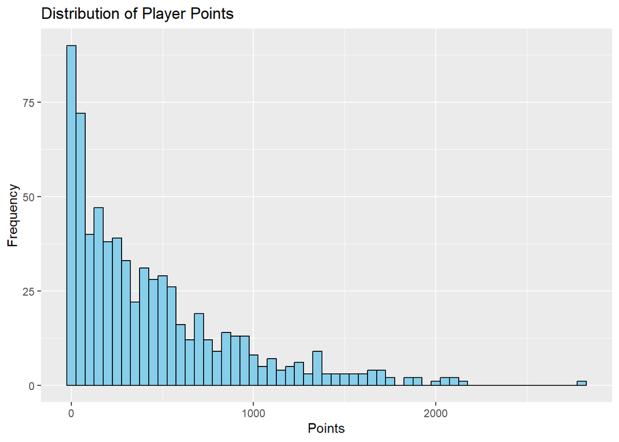

```r
ggplot(Complete_Data, aes(x = PTS_Player)) +
  geom_histogram(binwidth = 50, color = "black", fill = "skyblue") +
  ggtitle("Distribution of Player Points") +
  xlab("Points") +
  ylab("Frequency")
```

### Relationship between variables

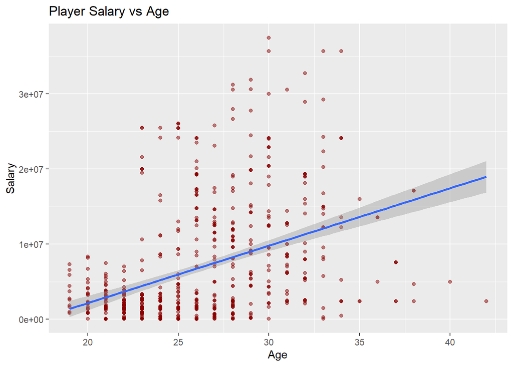

```r
# Visualize the relationship between variables
ggplot(Complete_Data, aes(x = Age_Player, y = salary_Player)) +
  geom_point(color = "darkred", alpha = 0.5) +
  ggtitle("Player Salary vs Age") +
  xlab("Age") +
  ylab("Salary")+
  geom_smooth(method = "lm")
```

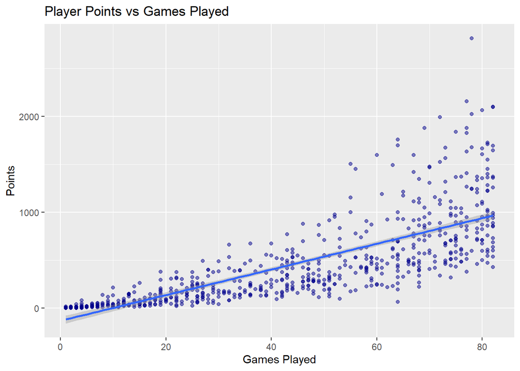

```r
ggplot(Complete_Data, aes(x = G_Player, y = PTS_Player)) +
  geom_point(color = "darkblue", alpha = 0.5) +
  ggtitle("Player Points vs Games Played") +
  xlab("Games Played") +
  ylab("Points")+
  geom_smooth(method = "lm")
```

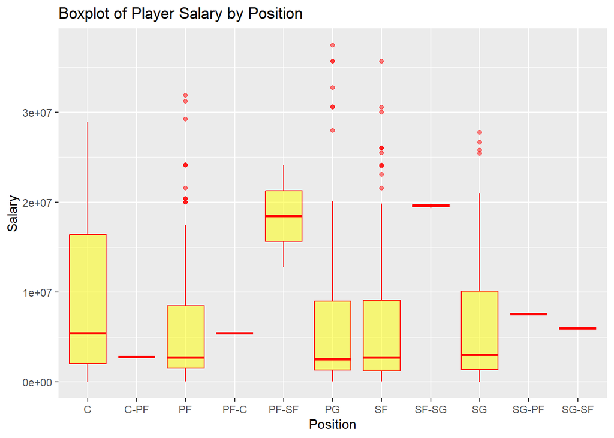

```r
# Plot a box plot of the player salary for each position
ggplot(Complete_Data, aes(x = Pos, y = salary_Player)) +
  geom_boxplot(color = "red", fill = "yellow", alpha = 0.5) +
  labs(x = "Position", y = "Salary",
       title = "Boxplot of Player Salary by Position")
```

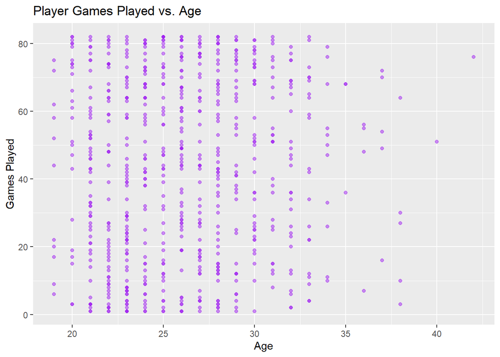

```r
# Plot a scatter plot of the player efficiency rating vs. player age
ggplot(Complete_Data, aes(x = Age_Player, y = G_Player)) +
  geom_point(color = "purple", alpha = 0.5) +
  labs(x = "Age", y = "Games Played", title = "Player Games Played vs. Age")
```

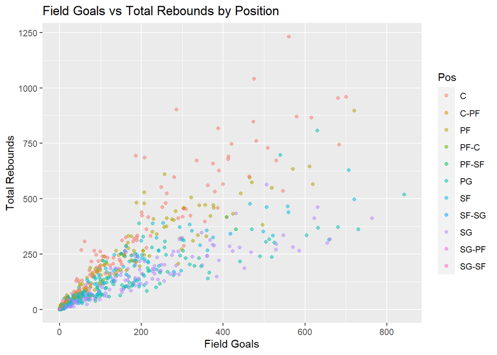

```r
ggplot(Complete_Data, aes(x = FG_Player, y = TRB_Player, color = Pos)) +
  geom_point(alpha = 0.5) +
  ggtitle("Field Goals vs Total Rebounds by Position") +
  xlab("Field Goals") +
  ylab("Total Rebounds")
```

The scatter plots and box plots are particularly helpful in identifying patterns and trends in your data.

In the scatter plot of player salary vs age, it appears that there is a slight positive correlation between these variables, with older players tending to earn higher salaries. The scatter plot of player points vs games played shows also a slight positive correlation, with players who have played more games generally having higher point totals.

### Tables

```r
# Create summary tables by position
pos_table = group_by(Complete_Data, Pos) %>%
  summarise(avg_salary = mean(salary_Player),
            avg_age = mean(Age_Player),
            avg_points = mean(PTS_Player),
            avg_rebounds = mean(TRB_Player)) %>%
  arrange(desc(avg_salary))

pos_table
```

```
## # A tibble: 11 × 5
##    Pos   avg_salary avg_age avg_points avg_rebounds
##    <fct>      <dbl>   <dbl>      <dbl>        <dbl>
##  1 SF-SG  19600928.    30.5      1028.         256
##  2 PF-SF  18453910     28.5       785          288
##  3 C       9376158.    27.2       485.         325.
##  4 SG-PF   7560000     37         600          162
##  5 SF      6598703.    26.1       406.         156.
##  6 PG      6552459.    26.0       476.         133.
##  7 PF      6189018.    25.7       397.         201.
##  8 SG-SF   6000000     29         366          126
##  9 SG      5891722.    25.9       446.         122.
## 10 PF-C    5450000     32          65           52
## 11 C-PF    2799720     21         323          202
```

```r
# Create a summary table by team
team_table = group_by(Complete_Data, Tm) %>%
  summarise(avg_salary = mean(salary_Player),
            avg_age = mean(Age_Player),
            avg_points = mean(PTS_Player),
            avg_rebounds = mean(TRB_Player)) %>%
  arrange(desc(avg_salary))

team_table
```

```
## # A tibble: 30 × 5
##    Tm    avg_salary avg_age avg_points avg_rebounds
##    <chr>      <dbl>   <dbl>      <dbl>        <dbl>
##  1 MIA     8650052.    27.3       482.         211.
##  2 GSW     8552820.    27.4       568.         223.
##  3 TOR     8357480.    27.1       427.         168.
##  4 POR     8273203.    24.5       526          216.
##  5 WAS     8185985.    26.6       374          139.
##  6 HOU     8136084     27.2       437.         158.
##  7 OKC     7975358.    25.2       508          228.
##  8 MIN     7731277.    27.1       456.         182.
##  9 CHA     7589962.    25.9       554          221.
## 10 BOS     7492734.    25.6       542.         215.
## # ℹ 20 more rows
```

# 4. Data modelling and results

Computing the Wins Above Replacement

$WAR = (TPC - Average.TPC)/10$

Computing the average Total Points Contributed $Average.TPC=TPC/Number.of.Players$

Computing the Total Points Contributed $TPC=PTS_{Player} + 1.25*(AST_{Player} + TRB_{Player}) + 1.5*STL_{Player} + 1.5*BLK_{Player} - 0.75*(FGA_{Player} - FG_{Player}) - 0.375*(FTA_{Player} - FT_{Player}) - TOV_{Player}$

```r
# create a new column for player's total points contributed (TPC)
Complete_Data = mutate(Complete_Data, TPC = PTS_Player + 1.25*(AST_Player + TRB_Player) + 1.5*STL_Player + 1.5*BLK_Player - 0.75*(FGA_Player - FG_Player) - 0.375*(FTA_Player - FT_Player) - TOV_Player)

# calculate the average TPC for all players
avg_TPC = mean(Complete_Data$TPC)

# calculate the player's individual WAR
Complete_Data = mutate(Complete_Data, WAR = ((TPC - avg_TPC) / 10))

# display the top 10 players by WAR
top10_WAR = Complete_Data %>% arrange(desc(WAR)) %>% head(10)
top10_WAR %>% select(1:7,"WAR") %>% pander::pander()
```

Table continues below

| Franchise | Tm | player_name | player_id |
| --- | --- | --- | --- |
| Houston Rockets | HOU | James Harden | 224 |
| Milwaukee Bucks | MIL | Giannis Antetokounmpo | 20 |
| Minnesota Timberwolves | MIN | Karl-Anthony Towns | 522 |
| Denver Nuggets | DEN | Nikola Jokic | 291 |
| Oklahoma City Thunder | OKC | Russell Westbrook | 548 |
| Detroit Pistons | DET | Andre Drummond | 157 |
| Orlando Magic | ORL | Nikola Vucevic | 535 |
| Utah Jazz | UTA | Rudy Gobert | 203 |
| Oklahoma City Thunder | OKC | Paul George | 197 |
| Golden State Warriors | GSW | Kevin Durant | 160 |

| salary_Player | Pos | Age_Player | WAR |
| --- | --- | --- | --- |
| 30570000 | PG | 29 | 263.6 |
| 24157304 | PF | 24 | 255.7 |
| 7839435 | C | 23 | 228.2 |
| 25467250 | C | 23 | 228 |
| 35665000 | PG | 30 | 225.1 |
| 25434262 | C | 25 | 219.4 |
| 12750000 | C | 28 | 217.7 |
| 23491573 | C | 26 | 212.8 |
| 30560700 | SF | 28 | 206.9 |
| 3e+07 | SF | 30 | 202.9 |

The WAR model computed evaluates a basketball player’s overall contribution to their team in terms of wins above a replacement player. The model is based on the concept of Total Points Contributed (TPC), which is a comprehensive measure of a player’s performance that takes into account points scored, assists, rebounds, steals, blocks, turnovers, and field goal and free throw attempts and makes. The TPC is then adjusted for the average TPC across all players to determine how much each player contributes to their team’s overall success relative to the average player.

The WAR model is used to evaluate the performance of NBA players and to identify the top performers in terms of overall contribution to their team’s success.

# 5. Player recommendations

```r
# Set budget limit
budget_limit = 118/5*1000000# Total planned budget per player

# Filter data to include only players within budget
Player_Selection = Complete_Data %>%
  filter(salary_Player <= budget_limit) %>%
  select(Franchise,player_name,Pos,Age_Player,WAR,salary_Player) %>%
  group_by(Pos) %>% arrange(desc(WAR))

# Select the top players based on WAR and Position
top_players = Player_Selection %>% group_by(Pos) %>% filter(WAR==max(WAR))

# View the selected players
top_players %>% pander::pander()
```

Table continues below

| Franchise | player_name | Pos | Age_Player | WAR |
| --- | --- | --- | --- | --- |
| Minnesota Timberwolves | Karl-Anthony Towns | C | 23 | 228.2 |
| Philadelphia 76ers | Ben Simmons | PG | 22 | 191.7 |
| Brooklyn Nets | Tobias Harris | PF | 26 | 156 |
| Dallas Mavericks | Luka Doncic | SG | 19 | 145 |
| Toronto Raptors | Kawhi Leonard | SF | 27 | 135.7 |
| Brooklyn Nets | Jimmy Butler | SF-SG | 29 | 107.5 |
| Brooklyn Nets | Kyle Korver | SG-PF | 37 | 2.366 |
| Brooklyn Nets | Wilson Chandler | PF-SF | 31 | -8.284 |
| Brooklyn Nets | Thon Maker | C-PF | 21 | -8.322 |
| Brooklyn Nets | Jonathon Simmons | SG-SF | 29 | -15.08 |
| Brooklyn Nets | Jason Smith | PF-C | 32 | -54 |

| salary_Player |
| --- |
| 7839435 |
| 6434520 |
| 14800000 |
| 6569040 |
| 23114066 |
| 19841627 |
| 7560000 |
| 12800562 |
| 2799720 |
| 6e+06 |
| 5450000 |

```r
#Top 5 best palyers in the league
Top_5=top_players %>% head(5)
Top_5 %>% pander::pander()
```

Table continues below

| Franchise | player_name | Pos | Age_Player | WAR |
| --- | --- | --- | --- | --- |
| Minnesota Timberwolves | Karl-Anthony Towns | C | 23 | 228.2 |
| Philadelphia 76ers | Ben Simmons | PG | 22 | 191.7 |
| Brooklyn Nets | Tobias Harris | PF | 26 | 156 |
| Dallas Mavericks | Luka Doncic | SG | 19 | 145 |
| Toronto Raptors | Kawhi Leonard | SF | 27 | 135.7 |

| salary_Player |
| --- |
| 7839435 |
| 6434520 |
| 14800000 |
| 6569040 |
| 23114066 |

```r
#Total budget to be spent
sum(Top_5$salary_Player)
```

```
## [1] 58757061
```

Based on the top 5 players recommended by the WAR model, the Chicago Bulls could benefit from signing players who are in their prime years and have a high WAR.The potential players for recommendations for different position include:

**Karl-Anthony Towns**: A young and dominant center, Towns could be a valuable addition to the Bulls’ front court. At only 23 years old and with a WAR of 228, he has plenty of room for growth and could be a long-term solution for the Bulls at center.

**Ben Simmons**: Simmons is a versatile point guard who can contribute in multiple ways. At only 22 years old and with a WAR of 192, he has already proven to be a valuable player. With his ability to score, rebound, and facilitate the offense, he could help the Bulls in multiple areas.

**Tobias Harris**: A solid power forward with a WAR of 156, Harris could be a reliable scorer and rebounder for the Bulls. At 26 years old, he is in his prime and could be a good addition to the team’s frontcourt.

**Luka Doncic**: A young shooting guard with a lot of potential, Doncic could be a valuable addition to the Bulls’ backcourt. With a WAR of 145 at only 19 years old, he has already shown that he can contribute at a high level. His scoring and playmaking ability could make him a valuable asset for the team.

**Kawhi Leonard**: A proven veteran with a WAR of 136, Leonard could be a valuable addition to the Bulls’ lineup. As a small forward, he could provide scoring and defense on the perimeter. Although he is 27 years old, he has proven that he can perform at a high level in the playoffs, which could be valuable for the Bulls if they make a postseason run.

# 6. Summary

In addition to the top players, we also performed exploratory data analysis and found interesting insights, such as the distribution of player salaries and ages, the relationship between player points and games played, and the distribution of player salaries by position. The EDA indicated that young players were cheaper compared to old players.

One limitation of our model is that it only considers performance in the 2018-2019 season, and does not account for a player’s long-term potential or consistency over multiple seasons. Additionally, there may be other factors that contribute to a player’s value beyond the metrics used in our analysis, such as leadership qualities or off-court behavior. Therefore, it is important to consider these additional factors when making decisions about player acquisition and team building.

# 7. References

- Oliver, D. (2004). Basketball on paper: Rules and tools for performance analysis. Washington, DC: Potomac Books.
- Hollinger, J. (2019). The Essential Guide to Basketball Statistics. ESPN Books [link](http://www.espn.com/nba/hollinger/statistics/_/year/2019)
- Fearnhead, P. & Taylor, B. (2011). On Estimating the Ability of NBA Players. Journal of Quantitative Analysis in Sports, 7(3). [link](https://doi.org/10.2202/1559-0410.1298)
- Vangelis Sarlis, Christos Tjortjis, Sports analytics — Evaluation of basketball players and team performance, Information Systems, Volume 93, 2020, 101562, ISSN 0306-4379, https://doi.org/10.1016/j.is.2020.101562. [link](https://www.sciencedirect.com/science/article/pii/S0306437920300557)